# Dimensionality reduction techniques

## Exploratory analysis

Let’s first visualize ‘human’ and check correlations.

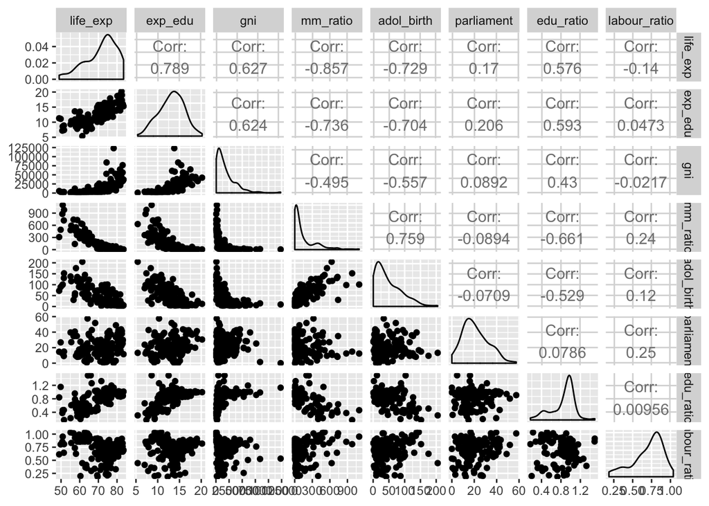

```
##              life_exp exp_edu   gni mm_ratio adol_birth parliament
## life_exp         1.00    0.79  0.63    -0.86      -0.73       0.17
## exp_edu          0.79    1.00  0.62    -0.74      -0.70       0.21
## gni              0.63    0.62  1.00    -0.50      -0.56       0.09
## mm_ratio        -0.86   -0.74 -0.50     1.00       0.76      -0.09
## adol_birth      -0.73   -0.70 -0.56     0.76       1.00      -0.07
## parliament       0.17    0.21  0.09    -0.09      -0.07       1.00
## edu_ratio        0.58    0.59  0.43    -0.66      -0.53       0.08
## labour_ratio    -0.14    0.05 -0.02     0.24       0.12       0.25
##              edu_ratio labour_ratio
## life_exp          0.58        -0.14
## exp_edu           0.59         0.05
## gni               0.43        -0.02
## mm_ratio         -0.66         0.24
## adol_birth       -0.53         0.12
## parliament        0.08         0.25
## edu_ratio         1.00         0.01
## labour_ratio      0.01         1.00
```

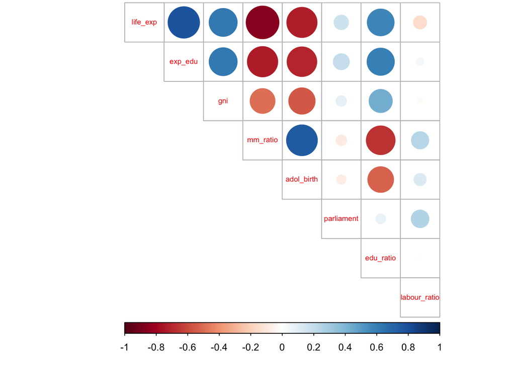

We can see that the highest correlations are observed between:

- life expectancy at birth and maternal mortality ratio: **-0.86**
- life expectancy at birth and expected years of education: **0.79**
- maternal mortality ratio and adolescent birth rates: **0.76**
- expected years of education and maternal mortality ratio: **-0.74**
- life expectancy at birth and adolescent birth rates: **-0.73**
- expected years of education and adolescent birth rates: **-0.7**

Most of the distributions are skewed, only expected years of education variable is close to normal distribution.